# Sieci neuronowe - projekt

## Instalacja

1.Instalowanie bibliotek

```r
install.packages('keras')
```

2.Ładowanie bibliotek Keras jako silnik wykorzystuje silnik TensorFlow

```r
library(keras)
library(dplyr, quietly = TRUE, warn.conflicts = FALSE)
library(ggplot2, quietly = TRUE, warn.conflicts = FALSE)
```

```r
install_keras()
```

fashion_mnist dataset - zbiór czarno-białych obrazków należących do 10 kategori. Każdy obrazek przedstawia jeden z 10 produktów firmy Zelando. Obrazki są słabej jakości - 28x28 piksel. Kazdy pixel ma skojarzoną z nim liczbę, która określa natężenie koloru - wartości od 0 do 255 (wieksza wartość oznacza ciemniejszy kolor). Zbiór uczący ma 785 kolumn (28x28 pikseli + etykieta klasy) Zbirór treningowy ma 60000 obserwacji, zbior testowy zaś 10000 obserwacj.

#Wczytywanie danych

```r
fashion <- dataset_fashion_mnist()
# zestaw uczacy
c(x_train, y_train) %<-% fashion$train
# zestaw testowy
c(x_test, y_test) %<-% fashion$test

#wektor z etykietami
class_names = c('T-shirt/top',
                'Trouser',
                'Pullover',
                'Dress',
                'Coat',
                'Sandal',
                'Shirt',
                'Sneaker',
                'Bag',
                'Ankle boot')
#wymiary
dim(x_train)
```

```
## [1] 60000    28    28
```

```r
dim(y_train)
```

```
## [1] 60000
```

Dane x - tablica 3-wymiarowa (etykieta, wysokosc, szerokosc) z wartosciami reprezentujacymi skalę szarości. Y sa liczbami całkowitymi z zakresu 0-9

## Wizualizacja pierwszych 25 elementow

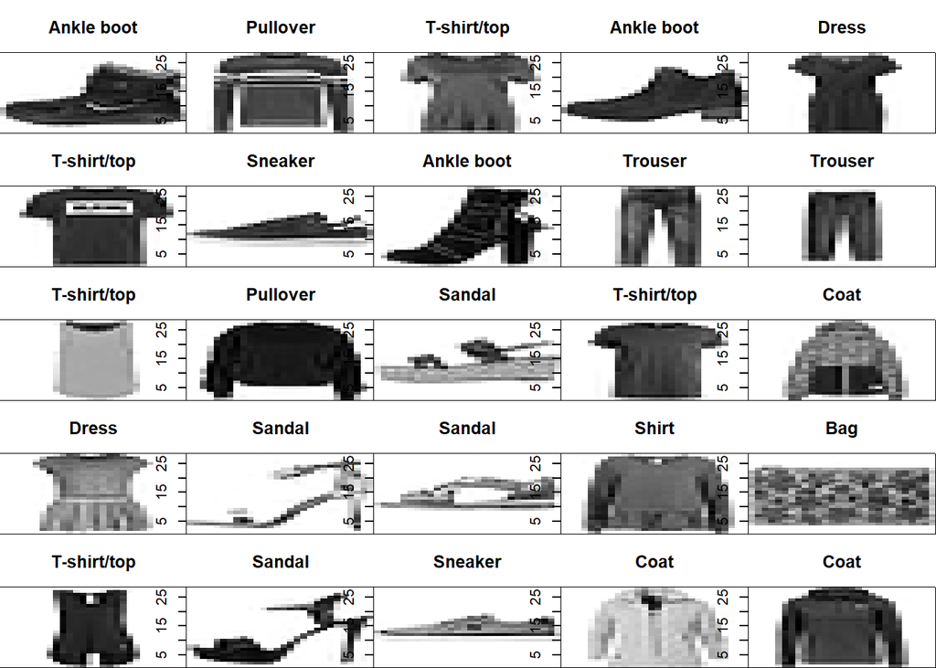

```r
par(mfcol=c(5,5))
par(mar=c(0,0,3,0), xaxs='i',yaxs='i')
for (i in 1:25){
  im <-x_train[i,,]
  im<-t(apply(im, 2, rev))
  image(1:28, 1:28, im, col=gray((255:0)/255),
        xaxt ='n', main = paste(class_names[y_train[i]+1]))
}
```

##Data preparation

```r
# zamiana rozmiaru tablicy 3-wymiarowej na 2 wymiarowa
x_train <- array_reshape(x_train, c(nrow(x_train),28*28))
x_test <- array_reshape(x_test, c(nrow(x_test),28*28))
dim(x_train)
```

```
## [1] 60000   784
```

```r
head(x_train, 25) # wyswietlam tablice po zmianie rozmiaru
```

[output not shown]

[output cut: 2195 more lines]

```r
#przeskalowanie - przechodzimy ze skali szarosci w rgb 0-255, do wartosci z zakresu 0-1. Normalizacja min-max
x_train <- x_train /255
x_test <- x_test /255

head(x_train, 1) # wyswietlam 1 element "przeskalowanej" tablicy
```

[output not shown]

[output cut: 143 more lines]

[output not shown]

```r
# Zmieniamy etykiety liczbowe na wektory "one-hot", które odpowiadają warstwie wyjsciowej naszego modelu. Dane wyjsciowe z sieci będą miały 10 wezłów, co odpowiada zdefiniowantm kategoriom produkótw (\obrazów).Funkcja to_categorical ustawia 1 dla najbardziej prawdopodobnej kategori, zas 0 da pozostalych. Czyli etykiety (10 elementów), zamieniamy na wektor 10 elementowy, w których każda współrzedna odpowiada danej klasie, i tak np dla klasy 5 ('Coat') mamy array array[[0.,0.,0.,0.,1.,0.,0.,0.,0.,0.]]
y_train <- to_categorical(y_train, 10)
y_test <- to_categorical(y_test, 10)
y_train[0]
```

```
## numeric(0)
```

## pierwsze 25 elementow z zestawu uczacego

```r
head(y_train, 25)
```

```
##       [,1] [,2] [,3] [,4] [,5] [,6] [,7] [,8] [,9] [,10]
##  [1,]    0    0    0    0    0    0    0    0    0     1
##  [2,]    1    0    0    0    0    0    0    0    0     0
##  [3,]    1    0    0    0    0    0    0    0    0     0
##  [4,]    0    0    0    1    0    0    0    0    0     0
##  [5,]    1    0    0    0    0    0    0    0    0     0
##  [6,]    0    0    1    0    0    0    0    0    0     0
##  [7,]    0    0    0    0    0    0    0    1    0     0
##  [8,]    0    0    1    0    0    0    0    0    0     0
##  [9,]    0    0    0    0    0    1    0    0    0     0
## [10,]    0    0    0    0    0    1    0    0    0     0
## [11,]    1    0    0    0    0    0    0    0    0     0
## [12,]    0    0    0    0    0    0    0    0    0     1
## [13,]    0    0    0    0    0    1    0    0    0     0
## [14,]    0    0    0    0    0    1    0    0    0     0
## [15,]    0    0    0    0    0    0    0    1    0     0
## [16,]    0    0    0    0    0    0    0    0    0     1
## [17,]    0    1    0    0    0    0    0    0    0     0
## [18,]    1    0    0    0    0    0    0    0    0     0
## [19,]    0    0    0    0    0    0    1    0    0     0
## [20,]    0    0    0    0    1    0    0    0    0     0
## [21,]    0    0    0    1    0    0    0    0    0     0
## [22,]    0    1    0    0    0    0    0    0    0     0
## [23,]    0    0    0    0    1    0    0    0    0     0
## [24,]    0    0    0    0    0    0    0    0    1     0
## [25,]    0    0    0    0    1    0    0    0    0     0
```

## definiowanie modelu

dense - standardowa warstwa sieci neuronowej, w ktorej każdy neuron jest połączony z każdym neuronem następnej warstwy. dropout - warstwa, która zapobiega “Overfittingowi”- nadmiernemu dopasowaniu sieci neuronowej do danych traningowych. Gdy pojawia sie overfitting to mamy bardzo dobre wyniki w zbiorach treningowych, zas w zbiorze testowym te wyniki są znacznie gorsze. Dropout w każdym cyklu uczenia ignoruje losowo wybrane neurony. model tworzymy podając kolejno warsty sieci neuronowe, w tym przypadku ograniczam sie do 4 warst typu Dense, które sa rozdzielone warstwami Dropout. kazda warstwa ma swoja funkcje aktywujaca, ostatnia warstwa musi miec funkcje aktywująca odpowiednią do typu zadania. Gdy do czynienia mamy z regresją liniowa, to ostatnia warstwa powinna miec funkcje aktywujaca liniowa -“linear”. Jeśli mamy do czynienia z klasyfikacja binarną (kategori A lub B) to funkcją aktywujacą powinna byc funkcja “sigmod”. Natomiast gdy mamy do czynienia z klasyfikacją wielowarstwową (tak jak w naszym przypadku (przypisywanie obrzka do jednej z 10 klas), wówczas uzywamy funkcji “softmax”. Funkcja “softmax” zwróci nam liste prawdopodobieństw przynależności próbki do danej klasy.  
Pierwsza warstwa musi zostać poinformowana o kształcie wektora wejsciowego: input_shape = 28*28, jest to wymóg biblioteki Keras. Ilośc warst oraz wielkość wektorów wyjściowych z każdej warsty są dowolne, ale dla ostatnij warstwy musimy przyjąć: dla regresji - 1 , dla klasyfikacji binarnej 2, zas dla wielkoklasowej n. a w naszym przypadku to jest unit =10 (10 klas do których będziemy przypisywać obserwacje)

```r
model <- keras_model_sequential()
model %>%
  layer_dense(units =512, activation = 'relu', input_shape = 28*28) %>%
  layer_dropout(rate = 0.5) %>%
  layer_dense(units =256, activation = 'relu') %>%
  layer_dropout(rate = 0.4) %>%
  layer_dense(units=128,activation = 'relu') %>%
  layer_dropout(rate = 0.3) %>%
  layer_dense(units = 10, activation = 'softmax')
```

## Podsumowanie stworzonego modelu

```r
summary(model)
```

```
## Model: "sequential"
## ___________________________________________________________________________
## Layer (type)                     Output Shape                  Param #
## ===========================================================================
## dense (Dense)                    (None, 512)                   401920
## ___________________________________________________________________________
## dropout (Dropout)                (None, 512)                   0
## ___________________________________________________________________________
## dense_1 (Dense)                  (None, 256)                   131328
## ___________________________________________________________________________
## dropout_1 (Dropout)              (None, 256)                   0
## ___________________________________________________________________________
## dense_2 (Dense)                  (None, 128)                   32896
## ___________________________________________________________________________
## dropout_2 (Dropout)              (None, 128)                   0
## ___________________________________________________________________________
## dense_3 (Dense)                  (None, 10)                    1290
## ===========================================================================
## Total params: 567,434
## Trainable params: 567,434
## Non-trainable params: 0
## ___________________________________________________________________________
```

## kompilacja modelu

```r
model %>% compile(
  loss = 'categorical_crossentropy', #fumkcja okreslajaca jak dokladny jesat model
  optimizer = optimizer_adam(),# w jaki sposób model jest uaktualniany, na podstawie pbserwowanych danych i strat.
  metrics = 'accuracy' #uzywana do monitorowania nauki i testowania
)
```

## uczenie

wywołanie metody fit rozpoczyna proces uczenia sieci neuronowej. Na wejściu podany zostaje przygotowany zbiór treningowy: x_train. Poniewaz, mamy do czynienia z uczeniem nadzowrowanym to podajemy również parametr y_train. epochs (epoki) - określa ile razy zbór treningowy=, zostanie wykorzystany w procesie uczenia. batch okresla jak często dokonujemy aktualizacji.

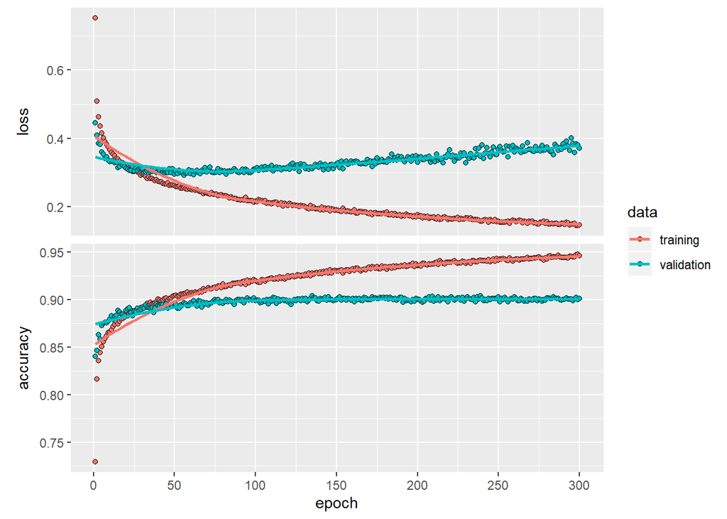

```r
model %>% fit(x_train,
              y_train,
              epochs = 300,
              batch_size = 128,
              validation_split = 0.2
              )-> model_dnn
plot(model_dnn)
```

## ewaluacja modelu

metoda evaluate zwraca wartośc strat oraz metryk dla modelu w trybie testowym

```r
model %>% evaluate(x_train, y_train) # Ocena skuteczności modelu na danych treningowych
```

```
## $loss
## [1] 0.1339984
##
## $accuracy
## [1] 0.9595833
```

```r
model %>% evaluate(x_test, y_test) # Ocena skuteczności modelu na danych testowych
```

```
## $loss
## [1] 0.3982273
##
## $accuracy
## [1] 0.8979
```

## predykcja

metdoa prediction zwarac tablice prawdopodobieństw, do której klasy należy dana obserwacja. Metoda ta służy do rzeczywistej prognozy

```r
model %>% predict(x_test) -> predictions # Prawdopodobienstwa dla danych testowych
model %>% predict_classes(x_test) -> predicted_digits # najbardziej prawdopodobna klasa

#Prawdopodobienstwa dla danych testowych:
head(predictions,1)
```

```
##             [,1]         [,2]         [,3]         [,4]         [,5]
## [1,] 1.67926e-29 2.580248e-26 2.484337e-26 3.525417e-29 1.753812e-28
##              [,6]         [,7]         [,8]         [,9] [,10]
## [1,] 4.027593e-12 5.964281e-32 1.781074e-08 1.854427e-32     1
```

```r
# najbardziej prawdopodobna klasa:
head(predicted_digits,1)
```

```
## [1] 9
```

## wizualizacja predykcji

Na czerwono zaznaczono błednie rozpoznane obrazki

[figure not shown]

```r
par(mfcol = c(5, 5))
par(mar = c(0, 0, 1.5, 0), xaxs = 'i', yaxs = 'i')
for (i in 1:25) {
  img <- fashion$test$x[i, , ]
  img <- t(apply(img, 2, rev))
  if (predicted_digits[i] == fashion$test$y[i]) {
    color <- '#008800'
  } else {
    color <- '#bb0000'
  }
  image(1:28, 1:28, img, col = gray((255:0) / 255), xaxt = 'n', yaxt = 'n',
        main = paste0(class_names[predicted_digits[i]+1], ' (',
                      class_names[fashion$test$y[i]+1], ')'),
        col.main = color)
}
```

## Macierz pomyłek

Oś X - “przewidywania” Oś Y - “odniesnienie kategorie wzorcowe”

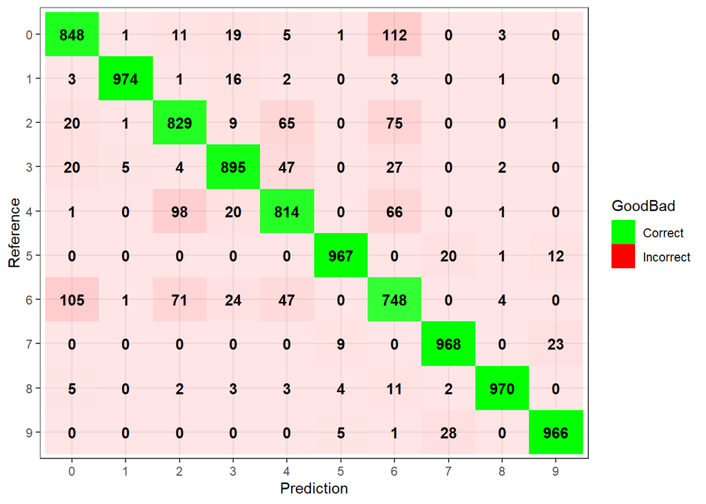

```r
data.frame(table(predicted_digits, fashion$test$y)) %>%
  setNames(c('Prediction', 'Reference', 'Freq')) %>%
  mutate(GoodBad = ifelse(Prediction == Reference, 'Correct', 'Incorrect')) -> conf_table

conf_table %>%
  ggplot(aes(y = Reference, x = Prediction, fill = GoodBad, alpha = Freq)) +
  geom_tile() +
  geom_text(aes(label = Freq), vjust = 0.5, fontface  = 'bold', alpha = 1) +
  scale_fill_manual(values = c(Correct = 'green', Incorrect = 'red')) +
  guides(alpha = FALSE) +
  theme_bw() +
  ylim(rev(levels(conf_table$Reference)))
```

przekątna wykresu, zaznaczona na zielono, opisuje prawidłowe rozpoznaie kategori. Liczby w zielonych polach prezentują poprawnie rozpoznane obrazki poza przękatna, zaznaczone sa błedne rozpoznania wraz z liczbą tych błedów.